# ¿Milagro o dictadura?: Una explicación del exito económico de Corea del Sur

Carlos Volcán y Diego Figuera

2 de diciembre de 2022

# Introducción

“El milagro económico de Corea del Sur no fue más que el resultado de incentivos y una gran dirección estatal” (Ha-Joong Chang)

Corea del Sur pasó de tener un PIB per cápita de USD 153,6 en 1960 a USD 34751,72 en 2021, lo que significa un incremento de 7% anual del mismo durante el periodo, porcentajes que los países desarrollados solo pueden envidiar. Incluso, es destacable que Corea del Sur fue devastada económicamente por la guerra de las coreas y su vecino del norte se encontraba en mejores condiciones económicas para el periodo 1953-1970. Lo que quiere decir que, para 1960, Corea tenía una economía post-guerra, con las menores reservas de recursos naturales del mundo y un deficiente capital humano.

Otros países en la época, como Venezuela, tenían unas condiciones iniciales totalmente distintas. En este caso, el estado venezolano recientemente aumentaba su participación en la industria petrolera nacional cambiando el fifty-fifty de Romulo Betancourt, asimismo era el mayor productor y exportador de petróleo del mundo con las mayores reservas, lo que generaba enormes rentas hacia el país. Sin embargo, Venezuela pasó de un PIB per capita de USD 953 a apenas USD 1690,66 en 2021 según estimaciones.

Con lo anteriormente descrito, definitivamente parece que Corea del Sur fue bendecida con un milagro económico. No obstante, dicha situación tiene una fácil explicación y es que el inesperado crecimiento económico se debe a la planificación estatal y el sistema de incentivos aplicado bajo la dictadura de Park Chun Hee, tercer presidente de la República de Corea que gobernó con mano férrea desde 1963 hasta su muerte en 1979, lo que significa más de 16 años de su politica económica. Es por eso que es importante analizar y comparar los resultados económicos de dichas políticas que se consideran el pilar del crecimiento de Corea del Sur.

# Datos utilizados

### Librerías necesarias

```r
library(tidyverse)
library(readxl)
library(ggthemes)
```

### Carga de datos

```r
gdp <- read_excel("base_limpia.xlsx", sheet = "gdp")
importcapacity <- read_excel("base_limpia.xlsx", sheet = "importcapacity")
pibeduc <- read_excel("base_limpia.xlsx", sheet = "pwt100")
```

### Presentación de los datos

En este caso, se extranjeron datos de varias fuentes oficiales que se mencionarán a medida que sea pertinente. Los mismos son para el periodo desde 1960, cuando Park Chung Hee dió un golpe de Estado antes de llegar al poder, hasta el 2018. Principalmente se utilizaron variables económicas como PIB, pib per cápita, para ver reflejada los resultados de las políticas de Park. Asimismo, los datos se extrajeron para tres países: Corea del Sur, Venezuela y Estados Unidos. Es importante que el lector este consciente de los siguientes conceptos:

1. **Producto interno bruto (PIB)**: valor agregado de la producción de bienes finales nacional, medido en dólares. Extraído de *Our World in Data.*
2. **Capacidad de importar:** es el valor de las exportaciones medido a precios de importaciones para determinar cuanto se puede comprar en el exterior con el flujo de divisa que entra a partir de las ventas hacia el resto del mundo. Extraído de *World Bank*.
3. **PIB per cápita**: distribución equitativa del la producción del país entre todos sus habitantes, frecuentemente utilizado como *proxy* del nivel de ingreso per cápita. *Calculo propio a partir de datos de Peen World Table 10.0 y Our World in Data.*
4. **Capital nominal:** valor del stock de capital que hay en la economía para un momento dado.
5. **Crecimiento económico:** cuanto crece o decrece el PIB de año a año. *Calculado a partir de datos de our World in Data.*

### Transformaciones realizadas

Se realizaron dos calculos a efectos de la investigación:

1. Se calculo el crecimiento económico;
2. Se calculo el PIB per cápita.

Su calculo se puede observar en el siguiente recuadro:

```r
#Calculo crecimiento economico:
gdp <- gdp %>%

  group_by(Entity) %>%

  mutate(growth = (GDP-lag(GDP))/lag(GDP)*100)

#Calculo PIB per capita:
pibeduc <- pibeduc %>%

  group_by(country) %>%

  mutate(pibperc = rgdpe/pop)
```

# Análisis descriptivo

Debe estar claro entonces que la cuestión principal es indigar sobre los efectos de las políticas del dictador Park sobre la economía surcoreano a corto y largo plazo. En resumidas cuentas, dichas políticas se basaron en una coordinación estatal masiva en todo el territorio e incentivos económicos para impulsar la economía. Entre las cosas más relevantes se encuentran:

1. Cuotas obligatorias de exportaciones a cumplir para los productores nacionales. Si no se cumplían, habían consecuencias legales;
2. Subsidio masivo de pérdida para las compañías que se dediquen a la investigación y desarrollo;
3. Incentivos fiscales a través de bajos impuestos a las ganancias empresariales;
4. Fuertes restricciones a la importación. Se decían los productos sujetos a importación y no los prohibidos de tan larga que era la lista.

Es destacable que, la economía surcoreana era mayoritamente regida por negocios familiares llamados en aquél entonces *chaebol*. Por ejemplo, la empresa más grande del país hoy día, Samsung, empezó como un chaebol vendiendo alimentos y gracias a la estrategia anterior ella y muchas otras se pudieron beneficiar para desplazarse hacia un sector técnologico hyper-rentable. Incluso, empresas como Hyundai se vieron forzadas por el gobierno a innovar. El gobierno surcoreano una vez les pidió un barco y ellos solo se dedicaban al automovilismo en la decada de los 70’s. Él mismo los obligó por la fuerza pero subsidiando su pérdida y hoy producen barcos.

Entonces se puede decir que la estrategia surcoronea se basó en sustitución de importaciones a través de los ingresos generados por las exportaciones. Incluso se puede observar el primer gráfico para ilustrar el tema:

### Gráfico 1 - poder de compra de importaciones

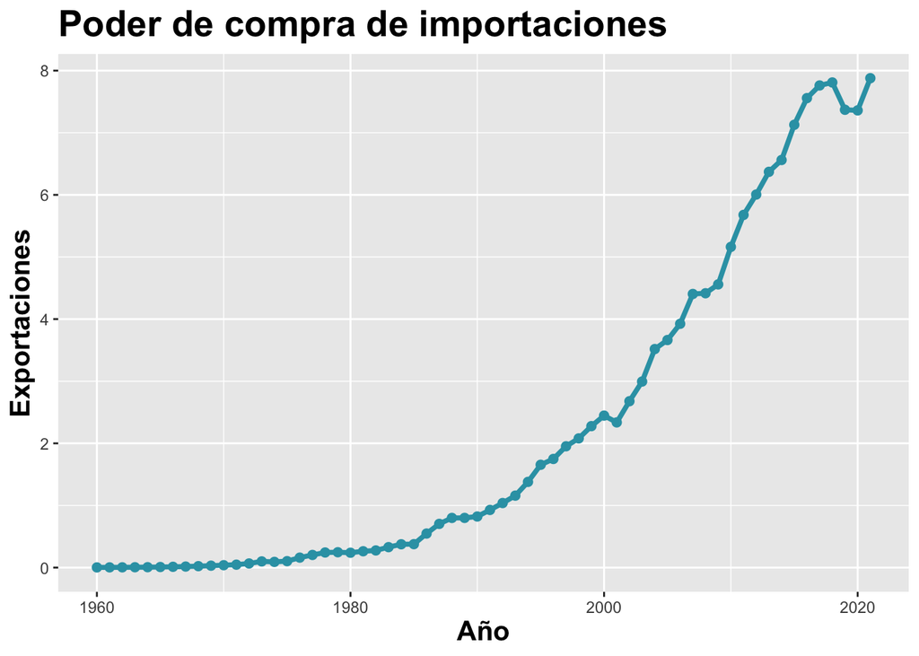

```r
importcapacity %>%

  filter(pais == "Korea, Rep.") %>%

  ggplot(aes(x = ano, y = importc/10^14)) +
  geom_line(aes(color = "#31A1B3" ), size = 1.3) +
  geom_point(aes(color = "#31A1B3"), size = 2) +

  xlab("Año") +
  ylab("Exportaciones") +
  ggtitle("Poder de compra de importaciones")+
  theme(plot.title = element_text(size = 20, face = "bold"),
        legend.position="none",
        axis.title.x = element_text(size = 15, face = "bold"),
        axis.title.y = element_text(size = 15, face = "bold")) +

  scale_color_manual(values = "#31A1B3")
```

Esto evidentemente generó un aumento del stock de capital en el país. A esto se le suma la ingeniosa y hábil fuerza de trabajo también promulgada por las políticas educativas de Park. Es mentira que no tenían nada antes de volverse la potencia que son hoy día. Ellos tenían el activo más valioso: capital humano. Inclusive luego de la guerra, los surcoreanos tenían el doble de años de educación que un venezolano en promedio. Aproximadamente estudiaban 5,2 años mientras que en Venezuela solo estudiaban 2,4 para finales de la década de los 60’s. Para los años 2000, el surcoreano promedio estudiaba 9,5 años mientras que el venezolano solo 5,5.

Definitivamente, esta combinación de acumulación de capital tanto físico como humano y estas políticas super expansiva propocionaron un ambiente lleno de emprendimiento y competitividad que impulso la producción nacional: A continuación se pueden ver una figura que ilustra lo dicho anteriormente comparándolo con Venezuela:

### Gráfico 2 - pib per cápita de Corea y Venezuela

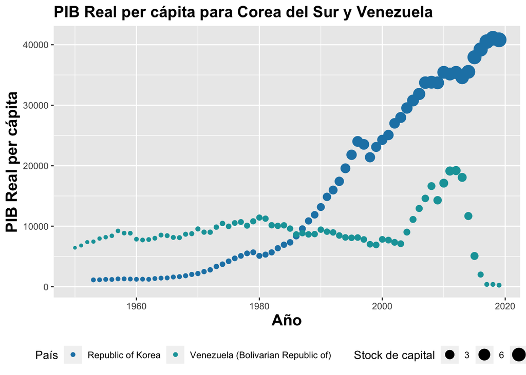

```r
pibeduc %>%

  filter(country %in% c("Republic of Korea", "Venezuela (Bolivarian Republic of)")) %>%

  ggplot(aes(x = year, y = pibperc, color = country, size = cn/10^6 )) +
  geom_point() +

  scale_color_tableau("Classic Cyclic") +

  xlab("Año") +
  ylab("PIB Real per cápita") +
  ggtitle("PIB Real per cápita para Corea del Sur y Venezuela")+
  theme(plot.title = element_text(size = 15, face = "bold"),
        axis.title.x = element_text(size = 15, face = "bold"),
        axis.title.y = element_text(size = 15, face = "bold"),
        legend.position = "bottom") +

  labs(size = "Stock de capital", col = "País")
```

En él se hace una comparación evidente. El tamaño de los circulos representa el stock de capital acumulado. La gráfica corresponde a una serie de tiempo del PIB per cápita de Venezuela y Corea del Sur. En teoría, Venezuela tiene uno de los recursos que más valió durante el siglo XX y sigue valiendo en el XXI: el petróleo. Tenía todas las de ganar e incluso hasta la época de los 80’s, en términos de PIB per cápita, Venezuela era mejor que Corea. Sin embargo, dado lo mencionado de la acumulación de capital físico y humano, era solo cuestión de tiempo para que Corea del Sur superara Venezuela.

### Gráfico 3 - crecimiento de Estados Unidos y Corea

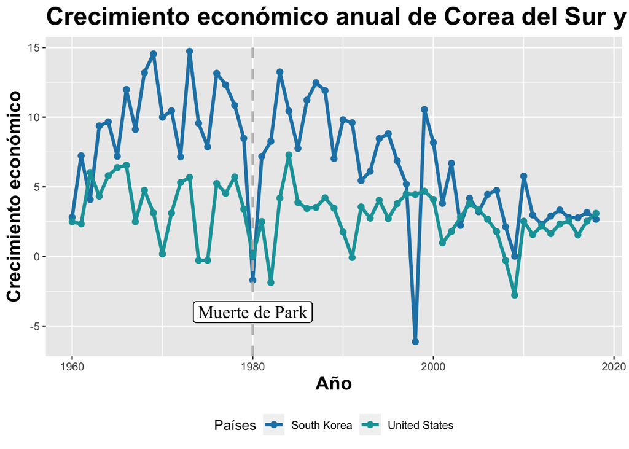

```r
gdp %>%

  filter(Entity %in% c("South Korea", "United States") & Year %in% c(1960:2020)) %>%

  ggplot(aes(x = Year, y = growth, color = Entity)) +
  geom_line(size = 1.3) +
  geom_point(size = 2) +

  geom_vline(xintercept = 1980, linetype = "dashed", color = "grey", size = 1) +

  xlab("Año") +
  ylab("Crecimiento económico") +
  ggtitle("Crecimiento económico anual de Corea del Sur y Estados Unidos") +
  guides(color = guide_legend(title = "Países")) +
  theme(plot.title = element_text(size = 20, face = "bold"),
        legend.position="bottom",
        axis.title.x = element_text(size = 15, face = "bold"),
        axis.title.y = element_text(size = 15, face = "bold"))+

  geom_label(aes(x = 1980, y = -4, label ="Muerte de Park"),
            size = 5, color = "black", family = "Times New Roman") +

  scale_color_tableau("Classic Cyclic")
```

### Gráfico 4 - ídem

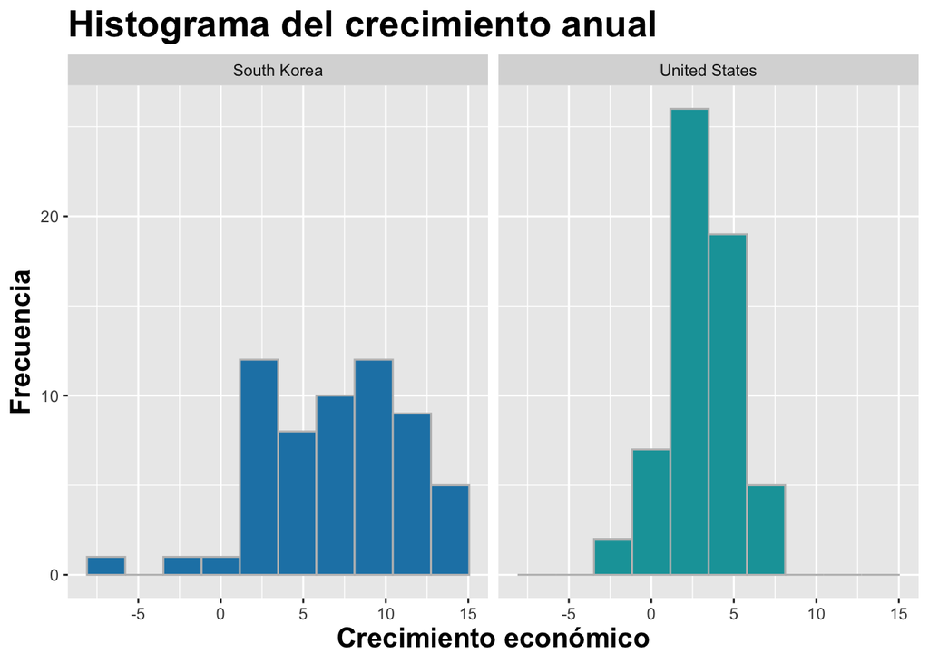

```r
gdp%>%

  filter(Entity %in% c("South Korea", "United States") & Year %in% c(1960:2020)) %>%

  ggplot(aes(growth, fill = Entity,)) +

  scale_fill_tableau("Classic Cyclic") +

  geom_histogram(bins = 10, color = "grey") +

  xlab("Crecimiento económico") +
  ylab("Frecuencia") +
  ggtitle("Histograma del crecimiento anual") +
  theme(plot.title = element_text(size = 20, face = "bold"),
        legend.position="none",
        axis.title.x = element_text(size = 15, face = "bold"),
        axis.title.y = element_text(size = 15, face = "bold")) +

  facet_grid(.~Entity)
```

De todas maneras, se denotan dos únicos periodos de decrecimiento para Corea: el primero fue en la muerte del presidente Park. El Movimiento Democrático de Gwangju. trató de tomar el poder por la fuerza pero fallaron pero a costa de cientos de muertes y daños a la economía. La segunda fue en la crisis bancaria asiática. Aún así, en el histograma se denota la distribución de frecuencias del crecimiento económico de Corea. A pesar de ser más achicado, esta más sesgado a la derecha que Estados Unidos y se puede reafirmar lo ya dicho con ello. La mayor parte se explica porque, como consecuencia de las políticas, la mayoría de esos negocios familiares se transformaron en empresas que ya no solo competían a nivel nacional, sino internacional. Para la decada de los 80’s todo la tecnología que alguna vez se exportab hacia Corea, ahora es producida allí.

Un último aspecto a destacar, es que todo esto ocurría a costa de ciertas libertades en el regimen de Park. No obstante, nunca hubo oposición de los surcoreanos hacia el regimen. No existían sindicatos ni organizaciones políticas, incluso algunos comentan que, como la sociedad era tan igual de pobre, nadie tenía que envidiarle a nadie y más bien la sociedad tenía el espíritu para salir adelante y las medidas de Park fueron como *anillo al dedo.*

# Conclusiones

El caso surcoreano no es ni milagro ni se le puede atribuir únicamente a las medidas tomadas por la dictadura de Park. Si es totalmente cierto que de haber elegido otro rumbo económico, probablemente estuviesen como sus vecinos del norte. Las cuatro medidas mencionadas al principio, restringieron las importaciones de bienes de consumo, fomentaron las exportaciones y la inversión en capital y fomentaron la investigación y el desarrollo. Pero, más allá de esto, la sociedad coreana atajó excelentemente las circunstancias. Una sociedad con espíritu innovador y resiliente. Hicieron la de *zero to hero*.

Sin embargo, también sería mentir al decir que la sociedad no tenía nada para empezar. Si tenían: educación y por lo tanto, capital humano. Combinado con lo anterior, Corea transformo sus divisas en inversión, aumento su capacidad de compra de importaciones, creció a un ritmo mucho mayor que países desarrollados y le ganó a otros que tenían cientos de veces los recursos naturales que ellos. Dicen que el milagro coreano es obra de una super-coordinación gubernamental en la economía, pero yo le sumaría que es obra de su forma de pensar también.

# Referencias

[Rodrik, D. (1994). *Getting interventions right:* *How South Korea and Taiwan Grew Rich.* National Bureu of Economic Research.] (https://www.jstor.org/stable/1344538)

[Wendover, P. (2022). *Samsung’s dangerous dominance on Korea.* Youtube.] (https://www.youtube.com/watch?v=oL0umpPPe-8&t=404s&ab_channel=WendoverProductions)